# Introduction to R: A Computational Workbench for Biological Data Analysis

Brian Capaldo

6/10/2017

# Acknowledgements

- [May Institute](https://computationalproteomics.ccis.northeastern.edu/)
  - [GitHub](https://github.com/MayInstitute/MayInstitute2017)
- Association of Biomolecular Research Facilities
- International Society for Advancement of Cytometry
- The R Project for Statisitcal Computing
- The Bioconductor Project
- [RStudio](https://www.rstudio.com/)
- UVA Office of Research Core Administration

# attributes(Brian)

- BS in Cellular and Molecular Biology
- Wet lab experience in yeast/bacterial genetics and materials science
- PhD in Biochemistry and Molecular Genetics
- Core informatician at UVA SOM ORCA
  1. Cytometry
  2. Mass spectrometry
  3. Next Generation Sequencing
  4. Microarrays
- [GitHub](https://github.com/bc2zb)

# Why R?

- It’s flexible (this presentation was made using R)
- It’s open source
- It’s widely supported
- Its design philosophy
- [Installing R](https://cran.r-project.org/)

# History of R

- The R programming language has its roots in S, a language created forty years ago at ATT Bell Labs by Chambers, Becker and Wilks.
- The motivation for S was to simplify the task of calling statistical routines written in FORTRAN (this involved writing code to read in, format and write out the data).
- The goal of S was to free users of the drudgery of writing that interface code and speed up the data analyst’s workflow. The key linguistic design principle was to design a language that could be extended and that was devoid of arbitrary limitations.
- The S language was such a success that users started writing statistical routines in S.
- The R programming language was designed by Ross Ihaka and Robert Gentleman at the University of Auckland around 1992.
- R departed from S in number of ways, it was an open source language released under a GPL license to ensure that everything related to R remains in the public domain, R cleaned up some corners of S and improve the performance of programs written in the language.

# R as a computational bench top

- Data as experiments
- Data structures as glassware
- Functions as instruments
- Vignettes as protocols

# Data types in R

The base types include `double`, `integer`, `characater` and `logical`. Values can be tested as belonging to one of those types.

```r
typeof(1)
```

```
## [1] "double"
```

```r
typeof(1L)
```

```
## [1] "integer"
```

```r
is.numeric(1.1)
```

```
## [1] TRUE
```

```r
is.logical(TRUE)
```

```
## [1] TRUE
```

```r
is.character("Hello")
```

```
## [1] TRUE
```

# Vectors

R provides several kinds of compound data structures commonly referred to as *vectors*. All operations in R are *vectorized*, this means that they take vectors as arguments and they will operate on the individual values (basic types) of these vectors.

```r
x <- c(1,2,2)   # 'c()' is the concatenate function
y <- c(2,2,1)
( x + y ) * x
```

```
## [1] 3 8 6
```

# Atomic vectors

Atomic vectors are homogeneous (possibly multi-dimensional) data structures.

```r
c(1,2,3)                # again using 'c()' to concatenate
```

```
## [1] 1 2 3
```

```r
c("one","two","three")
```

```
## [1] "one"   "two"   "three"
```

# Subsetting

All vectors can be accessed used subsetting operators `[` and `[[`

- `typeof()`
  - to find out what basic type is in the vector
- `length()`
  - how many elements are in it
- `attributes()`
  - query the vector’s meta data

# Element of vectors can be accessed individually.

```r
x <- c(1L, 2L, 3L) # The `L` lets R know you want an interger
x[1] <- 45
x[1]
```

```
## [1] 45
```

# A two dimensional atomic vector is called a *matrix* and higher-dimensional vector is called an *array*.

```r
a <- matrix(1:6, ncol = 3, nrow = 2)
b <- array(1:12, c(2,3,4))
```

# a

a <- matrix(1:6, ncol = 3, nrow = 2)

```r
a
```

```
##      [,1] [,2] [,3]
## [1,]    1    3    5
## [2,]    2    4    6
```

# b

b <- array(1:12, c(2,3,4))

```r
b
```

```
## , , 1
##
##      [,1] [,2] [,3]
## [1,]    1    3    5
## [2,]    2    4    6
##
## , , 2
##
##      [,1] [,2] [,3]
## [1,]    7    9   11
## [2,]    8   10   12
##
## , , 3
##
##      [,1] [,2] [,3]
## [1,]    1    3    5
## [2,]    2    4    6
##
## , , 4
##
##      [,1] [,2] [,3]
## [1,]    7    9   11
## [2,]    8   10   12
```

# Dynamic typing and coercions

Matrices and array, like vectors, are homogeneous, but it is possible to assign values of different basic types into any one of them. This causes a *coercion* of the entire data structure.

```r
x
```

```
## [1] 45  2  3
```

```r
x[[1]] <-1.1
x
```

```
## [1] 1.1 2.0 3.0
```

```r
a
```

```
##      [,1] [,2] [,3]
## [1,]    1    3    5
## [2,]    2    4    6
```

```r
a[[2,1]] <- "one"
a
```

```
##      [,1]  [,2] [,3]
## [1,] "1"   "3"  "5"
## [2,] "one" "4"  "6"
```

# R has a powerful set of subsetting operations that apply to all vectors uniformly. R allows, to subset ranges, rows, columns of vectors.

```r
a[1,]       # subset the first row
```

```
## [1] "1" "3" "5"
```

```r
a[1:2,]     # subset a range consisting of the first and second row
```

```
##      [,1]  [,2] [,3]
## [1,] "1"   "3"  "5"
## [2,] "one" "4"  "6"
```

```r
a[1:2,2:3]  # subset a range consisting of the first and second row and the second and third column
```

```
##      [,1] [,2]
## [1,] "3"  "5"
## [2,] "4"  "6"
```

# Coercions

```r
aa <- as.integer(a) # as.___ functions coerce one type into another
a
```

```
##      [,1]  [,2] [,3]
## [1,] "1"   "3"  "5"
## [2,] "one" "4"  "6"
```

```r
aa
```

```
## [1]  1 NA  3  4  5  6
```

```r
aa
```

```
## [1]  1 NA  3  4  5  6
```

```r
dim(aa) <- c(2,3) # dim() refers to the dimension of the data structure
aa
```

```
##      [,1] [,2] [,3]
## [1,]    1    3    5
## [2,]   NA    4    6
```

```r
a[1, a[1,] > 1] # here we are subsetting the first row of a and returning which positions are > 1
```

```
## [1] "3" "5"
```

```r
aa[1, aa[1,] > 1]
```

```
## [1] 3 5
```

# When using a predicate such as `a[1,] > 1` for subsetting, behind the scenes R generates a vector of logical values. True indicates a position that should be extracted. So this is:

```r
aa[1,]>1
```

```
## [1] FALSE  TRUE  TRUE
```

# We can use logical arrays to subset as follows:

```r
aa[1, c(FALSE, TRUE, TRUE)]
```

```
## [1] 3 5
```

# Subsetting can be used in assignment operations as well.

```r
a
```

```
##      [,1]  [,2] [,3]
## [1,] "1"   "3"  "5"
## [2,] "one" "4"  "6"
```

```r
a[1:3] <- a[4:6]
a
```

```
##      [,1] [,2] [,3]
## [1,] "4"  "6"  "5"
## [2,] "5"  "4"  "6"
```

# Lists

Lists are heterogeneous vectors. The elements of list can be of any kind, including lists and vectors.

```r
list(1, "hi", c(1,2))
```

```
## [[1]]
## [1] 1
##
## [[2]]
## [1] "hi"
##
## [[3]]
## [1] 1 2
```

The `typeof()` a list is `list`. You can test for a list with `is.list()` and coerce to a list with `as.list()`. You can turn a list into an atomic vector with `unlist()`. If the elements of a list have different types, `unlist()` will coerce.

# Referential transparency

To facilitate equational reasoning, R attempts to provide *referential transparency* for function calls. Referential transparency means that arguments are not changed by the function being called. So the following function `f(x)` does not modify the vector passed in.

```r
x
```

```
## [1] 1.1 2.0 3.0
```

```r
f <- function(x) { x[1] <- 1 }
f(x)
x
```

```
## [1] 1.1 2.0 3.0
```

# Questions on the basics of R?

# Packages

- In R, collections of data, functions, and compiled code are stored as *packages*. *Packages* can be thought of as the computational benchtop equivalent of the reagents and instruments required to perfrom a specific computational assay.
- There are two primary repositories from which to get *packages*, [CRAN](https://cran.r-project.org/) and [Bioconductor](http://bioconductor.org/)
- Bioconductor has made available a number of previous [courses](http://bioconductor.org/help/course-materials/) as well

# Installing packages from CRAN

```r
install.packages("tidyverse", verbose = T, repos='http://cran.us.r-project.org')
```

# Installing packages from Bioconductor

```r
source("https://bioconductor.org/biocLite.R")
```

```
## Bioconductor version 3.5 (BiocInstaller 1.26.0), ?biocLite for help
```

```r
biocLite("flowCore", verbose = T, suppressUpdates = T)
```

```
## BioC_mirror: https://bioconductor.org
```

```
## Using Bioconductor 3.5 (BiocInstaller 1.26.0), R 3.4.0 (2017-04-21).
```

```
## Installing package(s) 'flowCore'
```

```
##
##  /var/folders/d_/gyqsqcq13m7_kcpx9hxdxx540000gn/T//Rtmp8pHiP8/downloaded_packages
```

# Loading libraries

```r
library(flowCore)
library(tidyverse)
```

# Read Files

```r
file.name <- system.file("extdata","0877408774.B08", package="flowCore")
x <- read.FCS(file.name, transformation=FALSE)
summary(x)
```

```
##             FSC-H     SSC-H    FL1-H     FL2-H    FL3-H     FL1-A
## Min.      85.0000   11.0000   0.0000    0.0000   0.0000    0.0000
## 1st Qu.  385.0000  141.0000 233.0000  277.0000  90.0000    0.0000
## Median   441.0000  189.0000 545.5000  346.0000 193.0000   26.0000
## Mean     491.9644  277.9105 439.1023  366.1567 179.7122   34.0766
## 3rd Qu.  518.0000  270.0000 610.0000  437.0000 264.0000   51.0000
## Max.    1023.0000 1023.0000 912.0000 1023.0000 900.0000 1023.0000
##             FL4-H   Time
## Min.       0.0000   1.00
## 1st Qu.  210.0000 122.00
## Median   279.0000 288.00
## Mean     323.5306 294.77
## 3rd Qu.  390.0000 457.50
## Max.    1022.0000 626.00
```

# Search Keywords

```r
keyword(x,c("$P1E", "$P2E", "$P3E", "$P4E"))
```

```
## $`$P1E`
## [1] "0,0"
##
## $`$P2E`
## [1] "0,0"
##
## $`$P3E`
## [1] "4,0"
##
## $`$P4E`
## [1] "4,0"
```

# Print Summary

```r
summary(read.FCS(file.name)) # if you weren't sure if this is the right file
```

```
##             FSC-H     SSC-H      FL1-H      FL2-H       FL3-H     FL1-A
## Min.      85.0000   11.0000    1.00000    1.00000    1.000000    0.0000
## 1st Qu.  385.0000  141.0000    8.13123   12.07901    2.246790    0.0000
## Median   441.0000  189.0000  135.16485   22.46790    5.674221   26.0000
## Mean     491.9644  277.9105  157.79417  105.98637    8.464880   34.0766
## 3rd Qu.  518.0000  270.0000  241.44182   50.93675   10.746078   51.0000
## Max.    1023.0000 1023.0000 3651.74127 9910.45856 3278.121151 1023.0000
##              FL4-H   Time
## Min.       1.00000   1.00
## 1st Qu.    6.61169 122.00
## Median    12.29826 288.00
## Mean     140.39784 294.77
## 3rd Qu.   33.37625 457.50
## Max.    9821.71889 626.00
```

# One FCS file

```r
x # Operator did not annotate the channels!
```

```
## flowFrame object '0877408774.B08'
## with 10000 cells and 8 observables:
##      name              desc range minRange maxRange
## $P1 FSC-H             FSC-H  1024        0     1023
## $P2 SSC-H             SSC-H  1024        0     1023
## $P3 FL1-H              <NA>  1024        0     1023
## $P4 FL2-H              <NA>  1024        0     1023
## $P5 FL3-H              <NA>  1024        0     1023
## $P6 FL1-A              <NA>  1024        0     1023
## $P7 FL4-H              <NA>  1024        0     1023
## $P8  Time Time (51.20 sec.)  1024        0     1023
## 147 keywords are stored in the 'description' slot
```

# Biaxial Plot

```r
library(ggcyto)
```

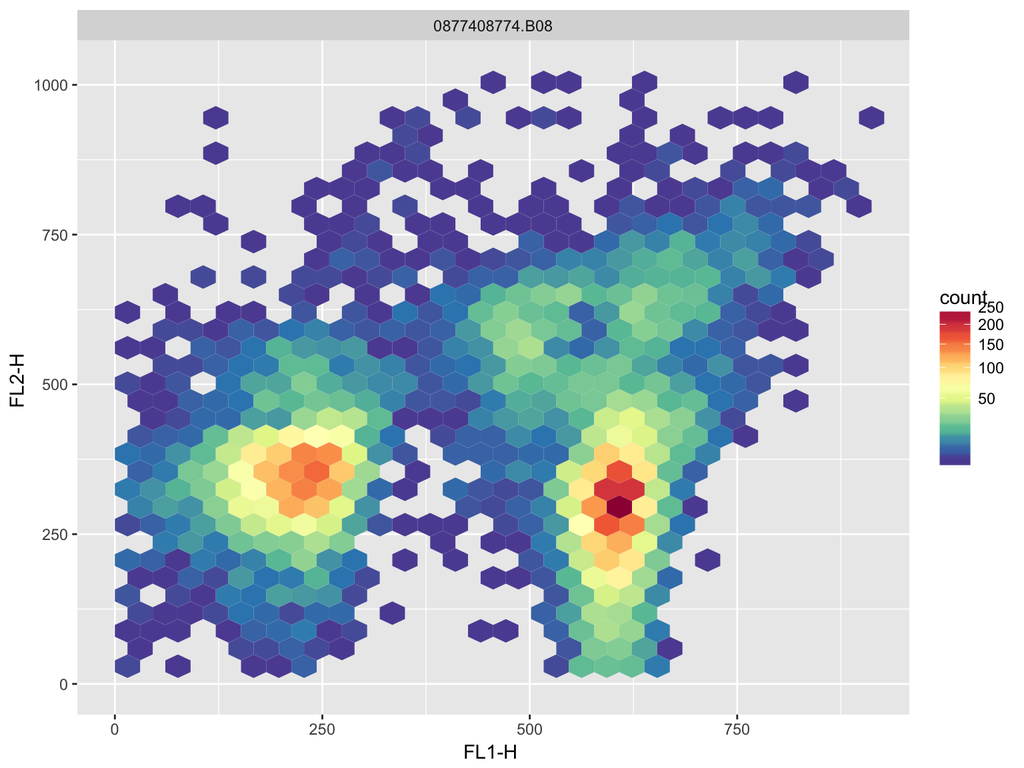

```r
autoplot(x, "FL1-H", "FL2-H")
```

# Histogram Plot

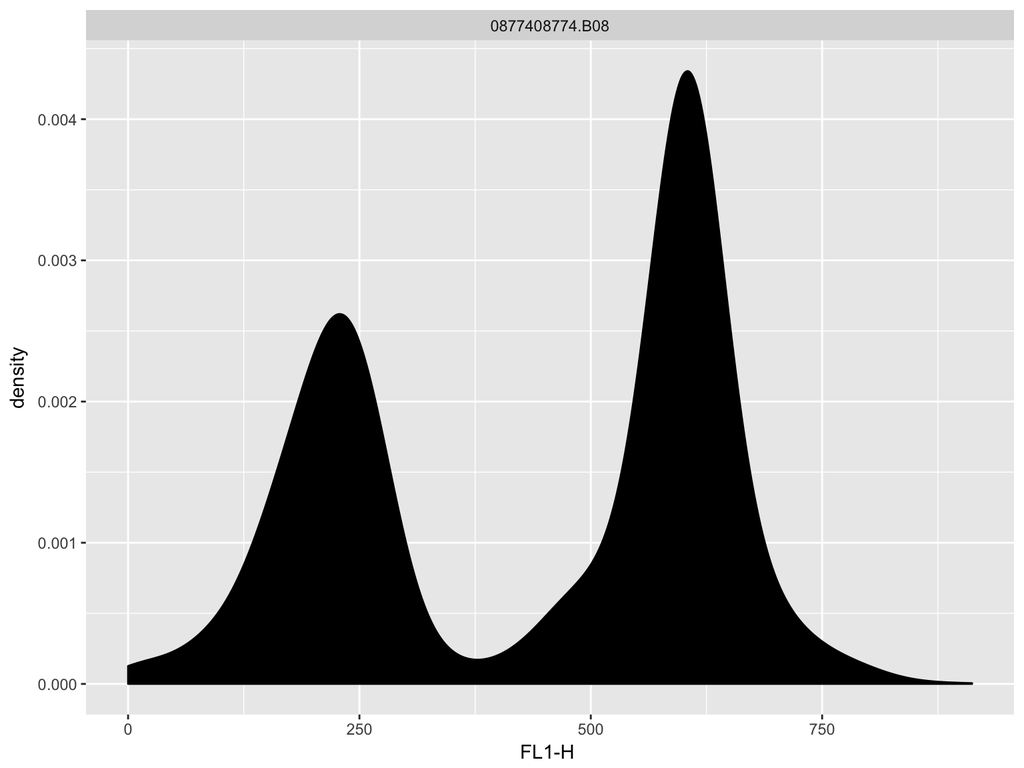

```r
autoplot(x, "FL1-H")
```

# Handling multiple FCS files

```r
frames <- lapply(                                      # member of apply family
                 dir(system.file("extdata",            # object to which function will be "applied"
                                 "compdata",           # system.file() is pointing to where the data is
                                 "data",
                                  package="flowCore"), # which package is the data stored in
                     full.names=TRUE),                 # returns the full file names
                 read.FCS)                             # function being applied
as(frames, "flowSet")                                  # casting all the frames as a flowSet
```

```
## A flowSet with 5 experiments.
##
##   column names:
##   FSC-H SSC-H FL1-H FL2-H FL3-H FL1-A FL4-H
```

# Storing a Flow Set

```r
names(frames) <- sapply(frames, keyword, "SAMPLE ID") # naming the frames in the flowSet
fs <- as(frames, "flowSet")                           # storing the flowSet as "fs"
fs                                                    # TIMTOWTDI
```

```
## A flowSet with 5 experiments.
##
##   column names:
##   FSC-H SSC-H FL1-H FL2-H FL3-H FL1-A FL4-H
```

# Annotating a flowSet

```r
phenoData(fs)$Filename <- fsApply(fs,        # another apply function
                                  keyword,   # applies keyword() on each frame in fs
                                  "$FIL")    # returns the $FIL (file name)
pData(phenoData(fs))                         # fs is now annotated with the file names
```

```
##      name   Filename
## NA     NA 060909.001
## fitc fitc 060909.002
## pe     pe 060909.003
## apc   apc 060909.004
## 7AAD 7AAD 060909.005
```

# Much more efficient method

```r
fs <- read.flowSet(path=system.file("extdata",
                                    "compdata",
                                    "data",
                                    package="flowCore"), # pointing to the data
                   name.keyword="SAMPLE ID",
                   phenoData=list(name="SAMPLE ID", Filename="$FIL")) # annotating the data
fs
```

```
## A flowSet with 5 experiments.
##
## An object of class 'AnnotatedDataFrame'
##   rowNames: NA fitc ... 7AAD (5 total)
##   varLabels: name Filename
##   varMetadata: labelDescription
##
##   column names:
##   FSC-H SSC-H FL1-H FL2-H FL3-H FL1-A FL4-H
```

```r
pData(phenoData(fs))
```

```
##      name   Filename
## NA     NA 060909.001
## fitc fitc 060909.002
## pe     pe 060909.003
## apc   apc 060909.004
## 7AAD 7AAD 060909.005
```

# Vignettes as Protocols

[ggcyto](http://bioconductor.org/packages/release/bioc/html/ggcyto.html)

[cytofkit](http://bioconductor.org/packages/release/bioc/html/cytofkit.html)

# Tour of RStudio

[RStudio](https://www.rstudio.com/)

# Resources

- Lab’s GitHub Repositories

  -[Nolan Lab](https://github.com/nolanlab)

  -[Gottardo Lab](https://github.com/rglab)
- Other labs to follow

  -[Irish Lab](https://my.vanderbilt.edu/irishlab/)

  -[Brinkman Lab](http://www.terryfoxlab.ca/people-detail/ryan-brinkman/)
- [Bioconductor Support](https://support.bioconductor.org/)
- [CyTOF Forum](http://cytoforum.stanford.edu/viewforum.php?f=1)
- Institutional Resources

# Next steps while here at CYTO 2017

- There are lots of posters about computational cytometry here
- Workshop 11: Automating High Volume Cytometry Data Analysis for Central Facilities

  Location: Room 302

  Date: Monday, Jun 12 15:45
- Keep posting questions on the [GitHub Issues Page](https://github.com/bc2zb/IntroductionToR/issues)